# 파이썬 특강 1부

## 들여쓰기

C, Java, Javascript 등 많은 언어에서 코드의 단락을 구분하기 위해 중괄호(`{}`)를 사용한다. 반면에 파이썬은 들여쓰기를 사용하여 코드단락(code block)을 구분한다. 또한 문장 구조의 복잡성을 들여쓰기의 정도로 구분하여 가독성과 코드단락의 시작과 끝을 명확히 한다.

예를 들어, 중첩된 `for` 반복문은 다음과 같이 작성한다. 들여쓰기에 주의하라.

```python
for i in [1, 2, 3]:             # 세미콜론 사용에 주의
    print(i)                    # "for i" 반복문 본체 단락(block) 시작
    for j in [1, 2, 3]:         # 세미콜론 사용에 주의
        print(j)                # 중첩된 "for j" 반복문 본체 단락 시작
        print(i + j)            # 중첩된 "for j" 반복문 본체 단락 끝
    print(i)                    # "for i" 반복문 본체 단락 끝
print("반복 완료")
```

```
1
1
2
2
3
3
4
1
2
1
3
2
4
3
5
2
3
1
4
2
5
3
6
3
반복 완료
```

## 줄바꿈

소괄호(`()`)와 대괄호(`{}`) 안에서는 공백문자(whitespace)가 무시된다. 따라서 다음과 같은 긴 계산을 할 때 줄바꿈을 이용할 수 있다.

```python
long_winded_computation = (1 + 2 + 3 + 4 + 5 + 6 + 7 + 8 + 9 + 10 + 11 + 12 +
                           13 + 14 + 15 + 16 + 17 + 18 + 19 + 20)

list_of_lists = [[1, 2, 3], [4, 5, 6], [7, 8, 9]]

easier_to_read_list_of_lists = [[1, 2, 3],
                                [4, 5, 6],
                                [7, 8, 9]]
```

줄바꿈을 괄호가 없을 경우 사용하려면 백슬래시(backslash)을 사용한다.

```python
two_plus_three = 2 + \
                 3
```

### 주의사항

책의 설명과 달리 빈 줄을 사용해도 오류가 발생하지 않는다. 아마도 파이썬이 업드레이드 되면서 달라진 요소로 보인다.

```python
for i in [1, 2, 3, 4, 5]:

    print(i)
```

```
1
2
3
4
5
```

반면에 들여쓰기 일정하지 않을 경우 오류가 발생하기 때문에 단락별 들여쓰기를 일정하게 유지해야 한다.

아래 코드에서 `print(i)` 명령문이 한 단계 더 들어가 있으며, 결과적으로 인덴테이션에러(`IndentationError`), 즉, 들여쓰기 오류가 발생한다.

```python
for i in [1, 2, 3, 4, 5]:
    i = i + 1
        print(i)
```

```
  File "<ipython-input-5-047fe881c30a>", line 3
    print(i)
    ^
IndentationError: unexpected indent
```

## 모듈과 패키지

파이썬을 실행할 때 기본적으로 사용할 있는 기능 이외의 것들을 사용하려면 관련 모듈과 패키지를 추가로 설치하거나 불러와야 한다.

### 모듈 불러오기

예를 들어, sin, cos, log, ceil, floor 등 다양한 수학 함수들을 사용하려면 `math` 모듈을 다음과 같이 불러와야 한다.

```python
import math
```

이제 `math` 모듈에 포함된 `log` 함수를 활용할 수 있다.

```python
log2 = math.log(2)
```

```python
log2
```

```
0.6931471805599453
```

즉, 특정 모듈에 포함된 함수나 변수를 사용하려면 아래 형식으로 호출한다.

```
모듈이름.함수이름(변수,...)
```

### 모듈 별칭 사용하기

모듈이름으로 별칭(alias, 에일리어스)을 사용할 수 있다. 별칭을 사용하는 이유는 주로, 이름을 간단하게 하기위해서이거나 이름이 중복되지 않게 하기 위해서이다.

별칭예제 1: `math` 모듈을 예를 들어 `m` 이라는 별칭으로 부를 수 있다. 단, 별칭을 사용하면 **반드시** 별칭으로만 사용해야 한다.

```python
import math as m
log2 = m.log(2)
log2
```

```
0.6931471805599453
```

#### 관습적 별칭

자주 사용되는 모듈에 대한 별칭은 커뮤너티에서 관습적으로 사용하는 별칭이 있다. 별칭에 대한 규정이 있지는 않지만 관습을 따르는 것이 혼동을 방지하며, 소스코드의 가독성과 협업의 효율성을 증대시킨다.

**주의:** `math` 모듈은 굳이 별칭을 사용하지 않는다. 앞에서는 별칭을 사용할 수 있다는 것을 보여주기 위함이었다.

별칭예제 2: 데이터를 시각화할 때는 맷플롯립(`matplotlib`) 패키지에 포함된 파이플롯(`pyplot`)이라는 모듈을 많이 사용하며, 관습적으로 `plt`라는 별칭을 사용한다.

아래 그래프는 대한민국 1인당 국민총소득(GNI)의 변천사를 1960년부터 5년 단위로 보여준다.

출처: 한국은행,「국민계정」, 통계청,「장래인구추계」

```python
import matplotlib.pyplot as plt
```

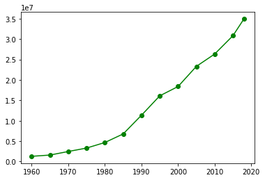

```python
years = [1960, 1965, 1970, 1975, 1980,
         1985, 1990, 1995, 2000, 2005,
         2010, 2015, 2018]
gdp = [1290000, 1600000, 2470000, 3310000, 4670000,
       6770000, 11340000, 16100000, 18380000, 23310000,
       26330000, 30830000, 34930000]

# 선그래프 그리기
plt.plot(years, gdp, color='green', marker='o', linestyle='solid')
```

### 패키지와 모듈

모듈은 파이썬 소스코드 파일을 가리키며 확장자가 `py`이다. 반면에 패키지는 여러 개의 모듈을 담고 있는 디렉토리, 즉 폴더를 가리킨다. 단, 폴더 안에 `__init__.py` 라는 특수 역할을 수행하는 파이썬 파일이 포함되어 있어야 한다.

- `__init__.py`는 해당 패키지와 관련된 여러 속성을 담는다. 특별한 속성이 필요하지 않을 경우 빈 파일로 두어도 된다.

예를 들어, `matplotlib` 패키지 (폴더) 안에는 `pyplot` 이외에 `path`, `patches`, `date` 등 사용 기능별로 구분된 함수와 변수들을 담은 모듈들이 포함되어 있다.

- 참조: 파이썬 모듈과 패키지에 대한 보다 자세한 설명은 아래 내용을 참조할 것을 추천한다.
  - 모듈: [점푸투파이썬 모듈](https://wikidocs.net/29)
  - 패키지: [점푸투파이썬 패키지](https://wikidocs.net/1418)

### 모듈의 특정 기능만 불러오기

모듈에 포함된 기능들 중에서 특정 기능 몇 개만 불러올 경우 해당 기능만 명시해서 불러올 수 있다.

아래 코드는 컬렉션즈(`collections`) 모듈에서 디폴트딕트(`defaultdict`) 함수와 카운터(`Counter`) 클래스만 불러온다.

**주의:** 모듈에서 특정 기능만 불러올 경우 모듈의 이름을 명시하지 않는다.

```python
from collections import defaultdict, Counter
lookup = defaultdict(int)
my_counter = Counter()
```

디폴트딕트(`defaultdict`) 함수와 카운터(`Counter`) 클래스의 활용은 이후에 자세히 살펴볼 예정이다.

### 좋지 않은 습관:

특정 모듈에 포함된 모든 기능을 한꺼번에 불러오는 것은 매우 좋지 않은 습관이다. 이유는 서로 다른 모듈에 동일한 이름의 중복되어 사용될 수도 있고 또 기존에 사용된 이름을 덮어쓰는 위험이 도사리기 때문이다.

아래 예제는 매치(`match`)라고 이미 선언된 변수가 정규표현식 모듈 `re`에 포함된 `match` 라는 다른 기능의 함수에 의해 덮어씌어지는 문제를 보여준다.

**주의:** 프로그래밍 언어에서 별표(`*`)는 일반적으로 모든 것(all)을 의미한다.

```python
match = 10
from re import *
print(match)
```

```
<function match at 0x7f65b498c158>
```

## 함수

임의의 개수의 인자를 받아 결과를 반환하는(return, 리턴) 일종의 규칙을 함수라 부르며, 파이썬에서는 데프(`def`)라는 키워드를 사용하여 함수 선언을 명시한다.

입력 인자 개수는 함수 선언에서 사용되는 매개변수의 개수로 지정된다. 아래에서 선언되는 함수 `double`은 매개변수를 `x` 하나만 사용한다. 즉, 인자를 하나 입력 받아 그 인자의 두 배를 반환하는 함수인 더블(`double`)을 선언한다.

```python
def my_double(x):
    """
    입력된 값을 두 배하여 반환한다.
    """
    return x * 2
```

**주의:**

- 함수 선언은 함수 이름과 해당 함수의 기능을 지정 하고 저장만 하며 실행하지는 않는다.
- 파이썬의 경우 매개변수의 자료형을 명시하지 않는다. 대신에 함수를 호출해서 실행할 때 적절하지 않는 인자가 입력되는 경우 오류를 발생시킨다.
- 함수를 선언할 때는 물론 특정 입력 인자들의 자료형을 생각하며 함수 본체를 구현한다. 따라서 함수를 호출할 때는 사용할 수 있는 인자의 개수와 각 인자들의 자료형을 알고 있어야 한다.

### 문서화 문자열(docstring)

함수 선언 본체(body)에 사용된 세 개의 큰따옴표는 주석을 지정할 때 사용되며, 함수의 기능을 설명하는 설명서 역할을 수행한다. 전문 용어로 문서화 문자열(docstring, 독스트링)이라 불리며, 소스코드의 구성과 구현과 관련된 내용을 문서화를 할 때 매우 유용하게 사용되는 기능이다.

예를 들어 `double` 함수에 대한 정보를 요구할 때 큰따옴표 안의 설명이 보여지며, 이를 위해 헬프(`help`) 함수를 이용한다.

```python
help(my_double)
```

```
Help on function my_double in module __main__:

my_double(x)
    입력된 값을 두 배하여 반환한다.
```

### 제1종 객체와 함수

파이썬에서 다루는 대상 중에 제1종 객체(first-class objects)는 변수에 할당되거나 함수의 인자로 사용될 수 있는 대상을 가리킨다.

파이썬의 경우 다루는 모든 대상이 제1종 객체이다. C 언어의 함수, Java 언어의 메소드(함수)는 제1종 객체가 아니다. 반면에 파이썬, 자바스크립트(Javascript) 언어에서 함수는 제1종 객체이다.

예를 들어, 아래에 정의된 함수 어플라이-투-원(`apply_to_one`)은 임의의 함수 `f`를 인자로 받아 `f(1)`의 값을 반환한다. 즉, 함수 `f(1)`을 실행한 결과값을 반환한다.

```python
def apply_to_one(f):
    """함수 f를 인자 1과 함께 호출한다."""
    return f(1)
```

따라서 `apply_to_one(my_double)`은 `my_double(1)`, 즉 2를 반환한다.

```python
apply_to_one(my_double)
```

```
2
```

### 람다(lambda) 함수

함수를 정의할 때 `def`라는 키워드를 사용해서 함수의 이름과 함수의 본체를 이용하여 함수를 선언하였다. 하지만 익명 함수, 즉 이름이 없는 함수를 선언할 수도 있으며, 이를 위해 람다(lambda) 기호를 사용한다.

람다 함수를 정의하는 형식은 다음과 같다.

```
lambda x1, x2, ..., xn: 반환값
```

위 정의는 n개의 인자를 받는 함수를 정의하며 `def` 키워드를 사용하면 아래 정의에 해당한다.

```
def 아무이름(x1, x2, ..., xn):
    return 반환값
```

예를 들어,

```
lambda x: x+4
```

는 숫자 하나를 입력 받으면 4를 더한 값을 반환한다.

따라서 이 함수를 `apply_to_one` 함수의 인자로 사용하면 5를 결과로 얻는다.

```python
apply_to_one(lambda x: x + 4)
```

```
5
```

두 개 이상의 인자를 받는 람다 함수의 예제는 다음과 같다. 아래 함수

```
lambda x y: (x + y)/2
```

는 인자 두 개를 입력받아 두 값의 평균값을 반환한다.

람다 함수에 인자를 입력하여 호출하는 방식은 다음과 같다.

```
(람다 함수)(인자1, 인자2, ..., 인자n)
```

예를 들어, 2와 4의 평균값을 다음과 같이 구할 수 있다.

```python
(lambda x, y: (x + y)/2)(2, 4)
```

```
3.0
```

#### 함수를 인자로 사용할 때 주의점

파이썬에서 함수 역시 제1종 객체이기 때문에 다른 함수의 인자로 사용할 수 있다. 다만 함수를 정의할 때 사용되는 매개변수의 자료형에 주의하면서 사용해야 하듯이 함수를 인자로 사용할 때 주의할 점이 두 가지 있다.

- 첫째: 인자 개수
- 둘째: 인자들의 자료형

예를 들어, `apply_to_one` 함수에 인자를 두 개 이상 받는 다변수 함수를 입력하면 오류가 발생한다. 이유는 하나의 인자만 받는 함수에 대해서만 정의되어 있기 때문이다.

```python
apply_to_one(lambda x, y: (x + y)/2)
```

```
---------------------------------------------------------------------------
TypeError                                 Traceback (most recent call last)
<ipython-input-20-9cc29bc777fb> in <module>
----> 1 apply_to_one(lambda x, y: (x + y)/2)

<ipython-input-16-ea9a93c68359> in apply_to_one(f)
      1 def apply_to_one(f):
      2     """함수 f를 인자 1과 함께 호출한다."""
----> 3     return f(1)

TypeError: <lambda>() missing 1 required positional argument: 'y'
```

또한 인자를 하나 받는 단변수 함수를 인자로 사용하더라도 해당 단변수 함수의 매개변수가 숫자가 아닌 값을 대상으로 할 경우 역시 오류가 발생한다.

```python
apply_to_one(lambda s: len(s))
```

```
---------------------------------------------------------------------------
TypeError                                 Traceback (most recent call last)
<ipython-input-21-cb17e17420b3> in <module>
----> 1 apply_to_one(lambda s: len(s))

<ipython-input-16-ea9a93c68359> in apply_to_one(f)
      1 def apply_to_one(f):
      2     """함수 f를 인자 1과 함께 호출한다."""
----> 3     return f(1)

<ipython-input-21-cb17e17420b3> in <lambda>(s)
----> 1 apply_to_one(lambda s: len(s))

TypeError: object of type 'int' has no len()
```

위에서 오류가 발생하는 이유는 `(lambda s: len(s))(1)`를 호출하다 보면 `len(1)`를 실행해야 하는 데 `len` 함수는 문자열의 길이를 반환하는 함수이며, 숫자 1은 문자열이 아니기 때문에 자료형오류(`TypeError`)가 발생하기 때문이다.

#### 람다 함수의 이름 지정

람다 함수를 변수에 저장할 수도 있지만 그럴바엔 애초부터 `def` 키워드를 사용해서 이름을 지정하는 것이 바람직하다.

```python
another_double = lambda x: 2 * x       # 바람직하지 않음.

def another_double(x):
    """이게 좋음"""
    return 2 * x
```

### 매개변수와 인자

함수를 선언할 때 입력받을 인자들을 저장하는 역할을 수행하는 변수를 **매개변수**(parameter)라 한다. 즉, 매개변수는 함수의 본체로 들어오는 값들의 입구들의 이름 역할을 수행한다. 반면에 인자(argument, 아규먼트)는 함수를 호출할 때 해당 함수의 매개변수를 통해 함수 본체에 전달되는 값을 가리킨다. 즉, 매개변수는 일종의 변수이고, 인자는 매개변수에 저장될 구체적인 값을 가리킨다.

앞서 설명한 제1종 객체가 함수의 인자로 사용될 수 있으며, 여기에 함수 자료형 자체도 포함된다.

#### 키워드 인자(keyword argument)와 기본값

함수의 매개변수에 기본값을 지정할 수 있으며, 그런 인자를 키워드 인자라 부른다. 이렇게 하면 특정 매개변수에 대한 인자를 지정하지 않은 채 함수를 호출할 수 있으며, 그럴 경우 기본값으로 지정된 키워드 인자가 해당 매개변수의 인자로 사용된다.

다음 `my_print` 함수의 둘째 매개변수 `message`의 키워드 인자는 `"hello!"` 이다.

```python
def my_print(do, message = "hello!"):
    print(do + ' ' + message)

my_print("say", "hi!")
my_print("say", message="hi!")
my_print("say")
```

```
say hi!
say hi!
say hello!
```

**주의:**

- 문자열들의 덧셈은 문자열 이어붙히기를 의미한다.
- `' '` 또는 `" "`는 스페이스 한 칸을 의미하는 문자열이다.

함수를 호출할 때 매개변수 이름을 함께 사용해도 된다.

```python
def full_name(last = "이름은", first = "아무개"):
    return last + " " + first

print(full_name("홍", "길동"))
print(full_name("홍"))
print(full_name(first="길동"))
```

```
홍 길동
홍 아무개
이름은 길동
```

## 문자열 자료형

문자열은 말 그래도 문자들을 나열해 놓은 것이며 아무런 의미를 갖지 않는다. 즉, 파이썬은 문자열을 보면 아무런 해석을 하지 않으며 그냥 명령에 따라 주어진 문자열을 조작한다. 물론 이런 문자열들을 잘 조작하여 필요한 정보를 얻어내는 것이 데이터 분석의 기본 목표이다.

문자열은 작은 따옴표(`'`) 또는 큰 따옴표(`"`)로 감싸져야 한다. 다만 앞 뒤로 동일한 종류의 따옴표가 사용되어야 한다.

```python
single_quoted_string = 'data science'
double_quoted_string = "data science"
```

두 변수가 동일한 값을 저장하고 있다는 것을 확인할 수 있다.

```python
single_quoted_string == double_quoted_string
```

```
True
```

**주의:** 위에서 사용된 기호 `==`는 양측의 값이 동일함을 판단하는 함수이다. 즉, 양측의 (변수에 저장된) 값이 동일하면 참(`True`)을, 다르면 거짓(`False`)를 반환하는 함수이다.

### 특수 문자

파이썬에서 백슬래시(`\`)는 특별한 역할을 수행한다. 예를 들어 `\t`는 탭을 가리킨다. 여기서 탭은 탭 키를 눌렀을 경우 커서(cursor)가 지정된 크기만큼 움직이도록 하는 것을 가리킨다.

```python
print("Hello,\tPython")
```

```
Hello,	Python
```

**주의:** 탭은 보통 스페이스 두 칸 또는 네 칸을 가리킨다. 언어마다 조금 다를 수 있다.

```python
print("Hello,  Python") # 스페이스 두 칸
```

```
Hello,  Python
```

```python
print("Hello,    Python") # 스페이스 네 칸
```

```
Hello,    Python
```

즉, 탭은 여기서는 스페이스 두 칸에 해당함을 알 수 있다.

백슬래시 자체를 문자열에 포함하고 싶을 때는 무가공 문자열(raw string, 로 스트링)이란 의미로 `r` 기호을 문자열 앞에 붙혀서 사용한다. 그러면 백슬래시의 특수성이 무시되면 하나의 문자로 인식된다.

```python
print(r'Hello,\tPython')
```

```
Hello,\tPython
```

### 여러 줄로 구성된 문자열

문자열을 여러 줄에 걸쳐서 작성하고 싶으면 세 개의 큰 따옴표(`"""`)를 앞뒤로 감싼다.

```python
multi_line_string = """첫째줄입니다.
둘째줄입니다.
셋째줄입니다."""
```

```python
print(multi_line_string)
```

```
첫째줄입니다.
둘째줄입니다.
셋째줄입니다.
```

파이썬 해석기에 내부에서는 사실 `\n` 이라는 특수 문자열이 추가되어 하나의 문자열로 저장된다. 여기서 `\n` 은 뉴 라인(new line, 줄바꿈)을 가리키는 특수 문자열이다. 역시 여기서도 백슬래시의 특수 기능이 활용된다.

```python
multi_line_string
```

```
'첫째줄입니다.\n둘째줄입니다.\n셋째줄입니다.'
```

### 포맷 문자열(format string)

문자열 내에 지정된 값을 삽입하여 보다 유연한 문자열을 생성할 수 있도록 도와주는 문자열을 포맷 문자열이라 부르며, 값을 인자로 입력받아 새로운 문자열을 생성하는 일종의 틀의 역할을 수행한다.

예를 들어, 성과 이름이 각각 `last_name`과 `first_name` 변수에 저장되어 있다.

```python
last_name = "홍"
first_name = "길동"
```

그러면 다음과 같이 문자열 덧셈을 이용하여 `'홍 길동'`을 생성할 수 있다.

```python
last_name + " "+ first_name
```

```
'홍 길동'
```

또한 포맷 문자열을 이용하여 좀 더 유연하게 문자열을 다룰 수 있다.

```python
"{1} {0}".format(first_name, last_name)
```

```
'홍 길동'
```

### f-문자열(f-string)

하지만 파이썬 최신 버젼부터는 f-문자열이 제공되며 편리성이 보다 높으며, 이 강의에서는 f-만자열을 선호해서 사용할 것이다.

```python
f"{last_name} {first_name}"
```

```
'홍 길동'
```

## 리스트 자료형

파이썬에서 제공하는 자료형 중에서 가장 기본적인 자료형이다. 리스트는 여러 개의 값을 하나의 모둠(collection)으로 묶는다. 또한 리스트에 포함된 값들 사이의 순서가 있으며, 순서는 인덱스(index)로 지정된다.

**주의:** 인덱스는 0번 부터 시작하며, 0, 1, 2, 3, ... 등으로 리스트 왼편에 위치한 항목부터 인덱스를 센다.

리스트 항목은 아무 자료형이나 섞어서 사용될 수 있다.

### 동일 자료형 리스트

```python
integer_list = [1, 2, 3]
```

### 섞인 자료형 리스트

```python
heterogeneous_list = ["string", 0.1, True]
```

### 중첩 리스트

리스트가 다른 리스트의 항목으로 사용될 수 있으며, 중첩 정도에 아무런 제한이 없다.

**주의:** `[]`는 아무런 항목이 없는 공리스트(empty list)를 가리킨다.

```python
list_of_lists = [integer_list, heterogeneous_list, []]
```

리스를 활용하는 많은 도구들이 있다.

### 리스트 길이

`len` 함수는 리스트의 길이를 반환한다.

```python
len(integer_list)
```

```
3
```

### 리스트 항목들의 덧셈

리스트 항목이 모두 숫자일 경우 모든 항목을 한꺼번에 더한 결과를 구할 수 있다.

```python
sum(integer_list)
```

```
6
```

### 인덱싱

리스트의 특정 인덱스에 위치한 값을 확인하거나 수정할 수 있으며, 이를 **인덱싱**이라 부른다. 기호는 대괄호(`[]`)를 사용한다.

```python
x = [0, 1, 2, 3, 4, 5, 6, 7, 8, 9]

zero = x[0]
one = x[1]
nine = x[-1]
eight = x[-2]
x[0] = -1

print(f"zero\t = {zero}",
      f"one\t = {one}",
      f"nine\t = {nine}",
      f"eight\t = {eight}",
      f"x\t = {x}",
      sep='\n')
```

```
zero	 = 0
one	 = 1
nine	 = 9
eight	 = 8
x	 = [-1, 1, 2, 3, 4, 5, 6, 7, 8, 9]
```

**주의:**

- 프린트(`print`) 함수는 인자를 여러 개 받을 수 있으며, 각 인자를 모두 화면에 출력해 주는 함수이다. `print` 함수의 각 인자들은 기본적으로 스페이스를 기준으로 한 줄에 출력되지만, 각 인자를 어떻게 구분해서 출력할지를 `sep`이라는 인자의 값을 조정하여 지정할 수 있다. 위에서는 줄바꿈(`\n`)을 `sep`에 대한 인자값으로 지정하여서 각 인자들이 여러 줄로 나뉘어 출력되었다.
- **역순 인덱스**(reverse index): 앞서 설명한 대로 인덱스는 리스트의 맨 왼편 항목부터 0, 1, 2, 3, ... 식으로 번호를 매긴다. 반면에 리스트의 맨 오른편 항목부터 -1, -2, -3, ... 을 이용하여 역순으로 인덱스를 매길 수도 있다. 따라서 -1은 리스트의 오른편 마지막 항목을 가리키며 종종 활용된다.

### 슬라이싱(slicing)

슬라이싱은 두 인덱스 사이의 항목을 선택하여 활용할 때 사용된다.

0번부터 2번 인덱스 항목 선택, 즉, 왼편 끝 첫 3개 항목 선택

```python
x[:3]
```

```
[-1, 1, 2]
```

3번 부터 끝까지 모두 선택

```python
x[3:]
```

```
[3, 4, 5, 6, 7, 8, 9]
```

1번부터 4번 항목까지 선택

```python
x[1:5]
```

```
[1, 2, 3, 4]
```

오른쪽 끝에서 3번째 항목부터 모두 선택, 즉, 오른쪽 끝 3개 항목 선택

```python
x[-3:]                 # [7, 8, 9]
```

```
[7, 8, 9]
```

양끝 항목 제외한 나머지 선택

```python
x[1:-1]
```

```
[1, 2, 3, 4, 5, 6, 7, 8]
```

전체를 선택하여 다른 변수에 저장

```python
copy_of_x = x[:]
print(copy_of_x)
```

```
[-1, 1, 2, 3, 4, 5, 6, 7, 8, 9]
```

#### 슬라이싱과 스텝(step)

스텝인자를 추가로 사용하면 몇 개마다 하나씩 선택할 수 있다.

예를 들어, 2번부터 오른쪽 끝 마지막 원소 전까지 3개씩 건너뛰며 항목 선택하려면 다음과 같이 한다. 즉, 2번, 5번, 8번 인덱스 항목만 선택된다.

```python
x[2:-1:3]
```

```
[2, 5, 8]
```

역순 슬라이싱도 가능하다. 스텝을 음수로 두면 된다. 아래 코드는 8번, 5번 인덱스 항목을 선택한다.

**주의:** 2번 인덱스 항목은 선택하지 않는다. 역순으로 2번 인덱스 이전 인덱스인 3번 인덱스까지만 해당되기 때문이다.

```python
x[8:2:-3]
```

```
[8, 5]
```

### 인(`in`) 연산자

`in`은 항목의 포함여부를 판단해 주는 연산자이다. 반환값은 `True` 또는 `False`이다.

**주의:** `True`와 `False`는 부울(`bool`) 자료형에 속하는 값들이다.

```python
1 in [1, 2, 3]
```

```
True
```

```python
0 in [1, 2, 3]
```

```
False
```

### 익스텐드(`extend`) 메소드

익스텐드(`extend`)는 기존 리스트에 새로운 리스트를 이어붙이도록 해주는 함수이다. 다만 리스트 자료형과만 함께 사용할 수 있으며, 이와 같이 특정 자료형에만 적용할 수 있는 함수를 **메소드**(method)라 부른다.

`extend`의 경우 리스트 자료형에만 사용하며, 따라서 리스트 메소드라 부른다.

```python
x = [1, 2, 3]
x.extend([4, 5, 6])
print(x)
```

```
[1, 2, 3, 4, 5, 6]
```

**주의:** `extend` 메소드는 기존 리스트를 변형시킨다. 따라서 기존의 리스트를 건드리지 않으면서 새로운 리스트가 이어진 리스트를 생성하려면 리스트 덧셈 연산자를 활용해야 한다.

```python
x = [1, 2, 3]
y = x + [4, 5, 6]
print(f"x = {x}", f"y = {y}", sep='\n')
```

```
x = [1, 2, 3]
y = [1, 2, 3, 4, 5, 6]
```

### 어펜드(`append`) 메소드

어펜드(`append`)는 기존 리스트에 새로운 항목을 하나씩 추가할 수 있도록 해주는 함수이다. `extend`처럼 `append`도 리스트 자료형과만 함께 사용할 수 리스트 메소드이다.

```python
x = [1, 2, 3]
x.append(0)
y = x[-1]
z = len(x)
print(f"x = {x}",
      f"y = {y}",
      f"z = {z}",
      sep='\n')
```

```
x = [1, 2, 3, 0]
y = 0
z = 4
```

**주의:**

- 엄밀한 메소드의 정의는 여기서는 다루지 않는다. 앞으로 많은 종류의 메소드를 살펴보게 될 것이다.
- 앞서 다뤘던 렌(`len`) 함수는 리스트 메소드가 아니다. 앞서 살펴 보았듯이 문자열과 리스트의 길이뿐만 아니라, 앞으로 살펴보게될 튜플, 사전 등 모든 모둠(collection) 자료형에 대해서도 동일한 기능을 수행하는 함수이다.

### 리스트 해체

리스트의 길이를 정확히 알고 있는 경우 각각의 항목을 따로따로 떼어내어 변수에 저장할 수 있다.

```python
x, y, z = [1, 2, 3]
print(f"x = {x}",
      f"y = {y}",
      f"z = {z}",
      sep='\n')
```

```
x = 1
y = 2
z = 3
```

**주의:** 리스트의 길이와 변수의 개수가 다르면 오류가 발생한다.

```python
x, y = [1, 2, 3]
```

```
---------------------------------------------------------------------------
ValueError                                Traceback (most recent call last)
<ipython-input-58-43d2015d9ce2> in <module>
----> 1 x, y = [1, 2, 3]

ValueError: too many values to unpack (expected 2)
```

```python
x, y, z, w = [1, 2, 3]
```

```
---------------------------------------------------------------------------
ValueError                                Traceback (most recent call last)
<ipython-input-59-6891ae448c90> in <module>
----> 1 x, y, z, w = [1, 2, 3]

ValueError: not enough values to unpack (expected 4, got 3)
```

리스트를 해체하면서 앞으로 사용하지 않고 버릴 항목은 굳이 이름을 주지 않아도 된다. 이를 위해 밑줄(`underscore`, 언더스코어) 기호를 사용한다.

```python
x, _, z = [1, 2, 3]
print(f"x = {x}",
      f"z = {z}",
      sep='\n')
```

```
x = 1
z = 3
```

## 튜플(tuple) 자료형

튜를 자료형은 리스트와 거의 같다. 다만 튜플 자료형은 한 번 생성되면 수정이 불가능하다. 즉, 앞서 리스트 인덱싱을 통해 기존 리스트의 항목을 수정할 수 있었지만 튜플의 경의 인덱싱을 통해 튜플의 항목을 확인하고 읽을 수만 있어서 수정은 불가능하다. 수정불가능성을 제외하고는 리스트와 기본적으로 동일하게 작동한다.

```python
my_list = [1, 2]   # 리스트
my_tuple = (1, 2)  # 튜플
```

### 수정 가능성

리스트는 인덱싱을 통해 특정 인덱스의 항목 수정이 가능하다.

```python
my_list[-1] = 3
print(my_list)
```

```
[1, 3]
```

반면에 튜플의 경우 수정을 시도하면 오류가 발생한다.

```python
try:
    my_tuple[1] = 3
except TypeError:
    print("튜플은 수정할 수 없어요.")
```

```
튜플은 수정할 수 없어요.
```

인덱싱을 통해 항목을 확인하여 활용할 수는 있다.

```python
x1 = my_tuple[0]
print(x1)
```

```
1
```

소괄호 없이 쉼표(comma, 콤마)를 이용하여 항목을 나열해도 튜플로 인식된다.

```python
other_tuple = 3, 4
type(other_tuple)
```

```
tuple
```

### 함수 반환값과 튜플 해체

함수는 실행과정에서 하나의 값만 반환할 수 있다. 하지만 튜플을 사용하면 여러 개의 값을 동시에 반환할 수 있다.

```python
def sum_and_product(x, y):
    return (x + y), (x * y)

sp = sum_and_product(2, 3)
s, p = sum_and_product(2, 3)

print(f"sp = {sp}", f"s  = {s}", f"p  = {p}", sep='\n')
```

```
sp = (5, 6)
s  = 5
p  = 6
```

### 변수 다중 할당

여러 개의 변수에 동시에 값을 할당하며 변수를 선언할 수 있다.

```python
x, y, z = 1, 2, 3
print(f"x = {x}", f"y = {y}", f"z = {z}", sep='\n')
```

```
x = 1
y = 2
z = 3
```

두 개 이상의 변수에 할당된 값들을 아래와 같이 교환할 수 있다.

```python
x, y, z = z, y, x
```

```python
print(f"x = {x}", f"y = {y}", f"z = {z}", sep='\n')
```

```
x = 3
y = 2
z = 1
```

**주의:** 위 교환방식은 파이썬과 최신 버전의 Javascript에서는 지원되지만 예를 들어 C, Java 에서는 지원되지 않는다.